# From Traffic Flow to Numerical Schemes

We just modeled traffic flow and arrived at the linear transport (advection) equation

$$u_t + a\,u_x = 0,\qquad a>0,$$

where $u(x,t)$ is the density and $a$ is the propagation speed.

Let a uniform grid be

$$x_j = j\,\Delta x,\qquad t^n = n\,\Delta t,\qquad u_j^n \approx u(x_j,t^n),\qquad
\lambda = \frac{a\,\Delta t}{\Delta x}.$$

**Pavni:** Last time we derived $u_t + a\,u_x=0$ from traffic flow. How do we solve it numerically?

**Acharya:** First, try the tempting FTCS (Forward in time, Central in space):

$$\frac{u_j^{n+1}-u_j^n}{\Delta t} + a\,\frac{u_{j+1}^n - u_{j-1}^n}{2\Delta x} = 0
\ \Longrightarrow\
u_j^{n+1} = u_j^n - \frac{\lambda}{2}\,(u_{j+1}^n - u_{j-1}^n).$$

**Pavni:** It looks symmetric and simple. Why not use it?

**Acharya:** Two reasons:

1. Direction of information (traffic logic). For $a>0$, information travels from left to right. FTCS is symmetric, so it lets the downstream value $u_{j+1}^n$ influence the update equally with the upstream value $u_{j-1}^n$. That clashes with the one-way nature of characteristics.
2. Instability (preview). FTCS for pure advection amplifies some Fourier modes (no built-in damping) and blows up. We will prove this with von Neumann analysis in the next level.

**Pavni:** So our spatial difference should look upstream.

**Acharya:** Exactly. That idea is upwinding.

## Deriving the Upwind Scheme

**Acharya:** For $a>0$, approximate $u_x$ by a backward (upwind) difference:

$$u_x(x_j,t^n) \approx \frac{u_j^n - u_{j-1}^n}{\Delta x}.$$

Use forward Euler in time for $u_t$:

$$\frac{u_j^{n+1}-u_j^n}{\Delta t} + a\,\frac{u_j^n - u_{j-1}^n}{\Delta x} = 0.$$

**Pavni:** Rearranging gives the update

$$\boxed{\,u_j^{n+1} = u_j^n - \lambda\,(u_j^n - u_{j-1}^n),\qquad \lambda=\frac{a\Delta t}{\Delta x},\ a>0.\,}$$

**Acharya:** If $a<0$ (information enters from the right), use a forward difference:

$$\boxed{\,u_j^{n+1} = u_j^n - \lambda\,(u_{j+1}^n - u_j^n),\qquad \lambda=\frac{a\Delta t}{\Delta x}<0.\,}$$

**Pavni:** So upwind means: differentiate in the direction information arrives from.

## What Upwind Does (Qualitative)

**Acharya:** Upwind is stable under a Courant (CFL) constraint and diffusive: sharp fronts smear slightly because the update is a convex combination of $u_j^n$ and its upstream neighbor.

**Pavni:** And FTCS?

**Acharya:** FTCS ignores directionality and is unstable for advection; save it for diffusion-type problems, not for pure transport.

**Note: CFL condition (preview)**

The Courant number $\lambda=a\Delta t/\Delta x$ should satisfy

$$\boxed{\,|\lambda| \le 1\,}$$

so that in one time step information does not jump over more than one cell.  
We will derive this precisely via von Neumann analysis next time.

**Note: Boundary conditions**

On a finite interval, specify inflow data only.  
For $a>0$, prescribe $u(0,t)$; the outflow boundary at $x=L$ needs no condition.  
For periodic problems, wrap indices: $u_{-1}^n \equiv u_{N-1}^n$.

### FTCS (for reference — unstable for advection)

$$u_j^{n+1}=u_j^n - \frac{\lambda}{2}(u_{j+1}^n - u_{j-1}^n)\quad\text{(unstable for advection)}.$$

- **Upwind, $a>0$:**
  $$\boxed{u_j^{n+1}=u_j^n-\lambda\,(u_j^n-u_{j-1}^n),\quad |\lambda|\le1.}$$
- **Upwind, $a<0$:**
  $$\boxed{u_j^{n+1}=u_j^n-\lambda\,(u_{j+1}^n-u_j^n),\quad |\lambda|\le1.}$$

**Pavni:** FTCS is elegant but the wrong tool for traffic.  
**Acharya:** Upwind respects the flow of information and gives us a reliable first solver.  
**Pavni:** We have seen that FTCS is unstable for advection and that Upwind works but is diffusive. What is next?

**Acharya:** A classic alternative is Lax-Friedrichs (LF). Think of it as FTCS plus pre-averaging: before updating, we average the two neighbors of $u_j^n$. That adds a touch of numerical viscosity and stabilizes the scheme.

**Pavni:** Pre-averaging? How does that enter the formula?

**Acharya:** Start from the PDE written with forward Euler in time and a central difference for space, but replace $u_j^n$ by the average $\tfrac12(u_{j+1}^n+u_{j-1}^n)$:
$$\frac{u_j^{n+1} - \tfrac12(u_{j+1}^n+u_{j-1}^n)}{\Delta t}
\;+\; a\,\frac{u_{j+1}^n - u_{j-1}^n}{2\,\Delta x} \;=\; 0.$$

**Pavni:** Rearranging gives the update?

**Acharya:** Exactly:
$$\boxed{~
u_j^{n+1}
= \tfrac12\,(u_{j+1}^n + u_{j-1}^n)
- \tfrac{\lambda}{2}\,(u_{j+1}^n - u_{j-1}^n).
~}$$

**Pavni:** This looks a lot like FTCS, but with the average replacing $u_j^n$.

**Acharya:** Right, and that averaging is the stabilizer. You can also rewrite LF to make the pieces more transparent:
$$u_j^{n+1}
= u_j^n
- \frac{\lambda}{2}\,(u_{j+1}^n - u_{j-1}^n)
+ \frac{1}{2}\,(u_{j+1}^n - 2u_j^n + u_{j-1}^n).$$
The last bracket is a discrete second derivative. It behaves like a diffusion term.

**Pavni:** So LF transports with a central difference and simultaneously smooths with a second difference.

**Acharya:** Precisely. That smoothing damps the modes that made FTCS blow up.

## CFL and behavior (what to remember now)

**Acharya:** Like Upwind, LF needs a Courant condition:
$$\boxed{~|\lambda| \le 1.~}$$

**Pavni:** And qualitatively?

**Acharya:** Stable and diffusive. Compared to Upwind, LF is typically more diffusive (more smoothing), because the pre-averaging adds extra numerical viscosity.

### Lax-Friedrichs (LF) scheme

$$\boxed{~
u_j^{n+1}
= \tfrac12\,(u_{j+1}^n + u_{j-1}^n)
- \tfrac{\lambda}{2}\,(u_{j+1}^n - u_{j-1}^n),\quad
\lambda=\frac{a\,\Delta t}{\Delta x},\quad |\lambda|\le 1.
~}$$

### Equivalent transport + diffusion form

$$\boxed{~
u_j^{n+1}
= u_j^n
- \frac{\lambda}{2}\,(u_{j+1}^n - u_{j-1}^n)
+ \frac{1}{2}\,(u_{j+1}^n - 2u_j^n + u_{j-1}^n).
~}$$

**Comparison cue**

- FTCS: central advection only -> unstable for advection.
- Upwind: one-sided advection -> stable, diffusive.
- Lax-Friedrichs: central advection + averaging -> stable, more diffusive.

## Why diffusive?

A short Taylor analysis shows LF approximately solves
$$u_t + a u_x \;\approx\; \frac{\Delta x^2}{2\Delta t}(1-\lambda^2)\,u_{xx},$$
hence the built-in smoothing. (We will derive this formally when we do modified equations.)

**Pavni:** So far we have: - FTCS: unstable,  
- Upwind: stable but diffusive,  
- Lax-Friedrichs: also stable, but even more diffusive.

Can we do better?

**Acharya:** Yes. The next natural step is the Lax-Wendroff (LW) scheme.  
It aims to achieve second-order accuracy in both time and space without excessive diffusion.

**Pavni:** Sounds good. How do we derive it?

### Derivation through Taylor expansion

**Acharya:** Start by expanding $u(x_j,t^{n+1})$ in a Taylor series in time:
$$u_j^{n+1}
= u_j^n + \Delta t\,u_t + \frac{\Delta t^2}{2}\,u_{tt} + \mathcal{O}(\Delta t^3).$$

Now use the PDE to eliminate time derivatives:

1. From the PDE: $u_t = -a u_x$.
2. Differentiate again: $u_{tt} = -a u_{xt} = -a(-a u_{xx}) = a^2 u_{xx}$.

Substitute back:
$$u_j^{n+1}
= u_j^n - a\Delta t\,u_x + \frac{a^2\Delta t^2}{2}\,u_{xx}.$$

**Pavni:** So we approximate $u_x$ and $u_{xx}$ with central differences?

**Acharya:** Exactly:
$$u_x \approx \frac{u_{j+1}^n - u_{j-1}^n}{2\Delta x}, \qquad
u_{xx} \approx \frac{u_{j+1}^n - 2u_j^n + u_{j-1}^n}{\Delta x^2}.$$

Substitute these into the Taylor expansion.

### The final Lax-Wendroff formula

**Acharya:** Combining all terms gives:

$$\boxed{
u_j^{n+1}
= u_j^n
- \frac{\lambda}{2}\,(u_{j+1}^n - u_{j-1}^n)
+ \frac{\lambda^2}{2}\,(u_{j+1}^n - 2u_j^n + u_{j-1}^n).
}$$

**Pavni:** Same stencil as Lax-Friedrichs. The only difference is the coefficient of that second-difference term.

**Acharya:** Exactly.  
Both schemes use $(u_{j+1}-2u_j+u_{j-1})$, but:

| Scheme | Coefficient on $u_{xx}$-like term |
| --- | --- |
| Lax-Friedrichs | $+\frac{1}{2}$ |
| Lax-Wendroff | $+\frac{\lambda^2}{2}$ |

### Accuracy and Stability

**Pavni:** So Lax-Wendroff should be more accurate?

**Acharya:** Yes, it is second-order accurate in both time and space.  
Like Lax-Friedrichs, it is stable under the same CFL condition:

$$\boxed{|\lambda| \le 1.}$$

However, while LF is diffusive, LW is dispersive: it does not smooth the solution, but may create small oscillations near steep gradients.

## Discussion: Diffusion vs. Dispersion

**Pavni:** Why does LW produce oscillations?

**Acharya:** Look at its modified equation.  
If we expand the numerical scheme in Taylor series, we find

$$u_t + a\,u_x
= -\,\frac{a\,\Delta x^2}{6}\,(1 - \lambda^2)\,u_{xxx} + \mathcal{O}(\Delta x^4).$$

That extra term involves the third derivative, not the second.  
Third derivatives do not damp amplitudes; they shift the phase of waves.

- A $u_{xx}$ term -> diffusion (damps high frequencies).
- A $u_{xxx}$ term -> dispersion (distorts wave shape).

**Pavni:** So the oscillations are phase errors, not amplitude errors.

**Acharya:** Exactly.  
That is why we say:  
Lax-Friedrichs is diffusive,  
Lax-Wendroff is dispersive.

### Lax-Wendroff scheme

$$\boxed{
u_j^{n+1}
= u_j^n
- \frac{\lambda}{2}\,(u_{j+1}^n - u_{j-1}^n)
+ \frac{\lambda^2}{2}\,(u_{j+1}^n - 2u_j^n + u_{j-1}^n), \quad |\lambda|\le1.
}$$

### Modified equation (reveals dispersion)

$$\boxed{
u_t + a\,u_x = -\frac{a\,\Delta x^2}{6}\,(1 - \lambda^2)\,u_{xxx}.
}$$

**Error type summary**

| Scheme | Leading error term | Effect on solution |
| --- | --- | --- |
| Upwind | $u_{xx}$ | Diffusive (smoothing) |
| Lax-Friedrichs | $u_{xx}$ | More diffusive |
| Lax-Wendroff | $u_{xxx}$ | Dispersive (oscillatory) |

## Problem (Comparison Plot)

We solve the 1-D linear advection (transport) equation on a periodic domain $x\in[0,1)$:
$$u_t + a\,u_x = 0,$$
with a Gaussian initial condition $u_0(x)=\exp\{-100(x-0.3)^2\}$ and compare three schemes:

- Upwind (first-order upwind; direction chosen by $\mathrm{sign}(a)$)
- Lax-Friedrichs (LF)
- Lax-Wendroff (LW)

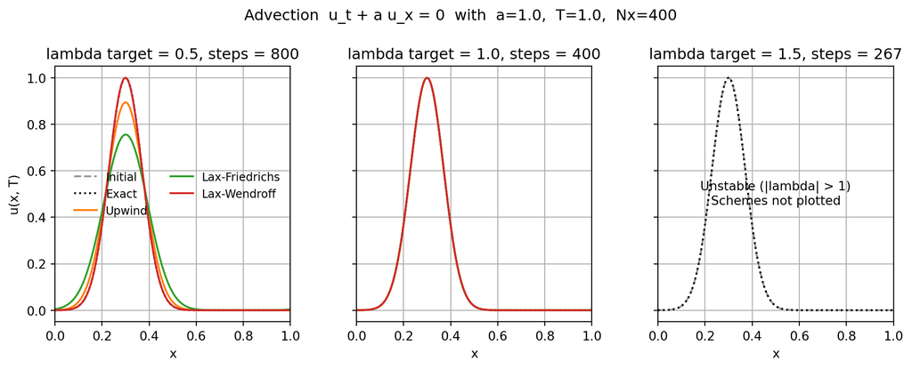